# Practicum 1

Omi Johnson ( johnson.omi@northeastern.edu ) and Bridget Leary ( leary.br@northeastern.edu )

**NOTE** Please run `CREATE DATABASE Practicum1` within MySQL workbench before attempting to run this code. We do not know how to create the database within R since we cannot establish a connection before it exists.

## Question 1: Establishing the Database

**Connecting to the database**

```r
# loading packages RMySQL and dplyr (for grouping)
packages <- c("RMySQL", "dplyr", "readr")
installed_packages <- packages %in% rownames(installed.packages())
if (any(!installed_packages)) {
  install.packages(packages[!installed_packages])
}
invisible(lapply(packages, library, character.only = TRUE))
# 1. Library
library(RMySQL)
library(dplyr)

# 2. Settings
db_user <- 'root'
db_password <- '587DJLOTL4mys'
db_name <- 'practicum1'
db_host <- 'localhost'
db_port <- 3306

# 3. Read data from db
mydb <-  dbConnect(MySQL(), user = db_user, password = db_password,
                 dbname = db_name, host = db_host, port = db_port)
```

```sql
SET GLOBAL local_infile = 1;
```

**Creating Tables**

```sql
DROP TABLE IF EXISTS incidents;
```

```sql
DROP TABLE IF EXISTS airports;
```

```sql
DROP TABLE IF EXISTS conditions;
```

**Airports**: We decided that only `airportName` needs to be not null, as `airportCode` and `airportState` may be unfilled in practice. We decided to add auto_increment for the `aid` for ease of insertion for new airport values.

```sql
CREATE TABLE IF NOT EXISTS airports (
  aid INTEGER NOT NULL PRIMARY KEY AUTO_INCREMENT,
  airportName TEXT NOT NULL,
  airportCode TEXT,
  state TEXT
);
```

**Conditions**: We decided that `ccondition` must be not null so that the row is meaningful. We chose to use auto_increment for the `cid` for ease of insertion.

```sql
CREATE TABLE IF NOT EXISTS conditions (
  cid INTEGER NOT NULL PRIMARY KEY AUTO_INCREMENT,
  ccondition TEXT NOT NULL, -- renamed to avoid overlap with reserved keyword
  explanation TEXT
);
```

**Incidents**:

```sql
CREATE TABLE IF NOT EXISTS incidents (
  rid INTEGER NOT NULL PRIMARY KEY,
  idate DATE NOT NULL, -- renamed to idate to avoid overlap with reserved keyword
  origin INTEGER NOT NULL,
  airline TEXT,
  aircraft TEXT,
  flightPhase TEXT,
  altitude INTEGER,
  conditions INTEGER,
  warning TINYINT(1),
  CONSTRAINT or_is_fk FOREIGN KEY (origin) REFERENCES airports(aid),
  CONSTRAINT con_is_fk FOREIGN KEY (conditions) REFERENCES conditions(cid),
  CHECK (flightPhase IN ('takeoff', 'landing', 'inflight', 'unknown'))
);
```

## Questions 1 & 2: Loading the data

```r
birdstrikes <- readr::read_csv("BirdStrikesData-V2.csv",
                               col_types = readr::cols())
```

### Data preprocessing

**Selecting and renaming relevant columns, removing null values**

Notes on missing values: We decided that the essential columns for an incident entry were rid and flight date. Every null value in relevant columsn of the `BirdStrikesData-V2.csv` file is in the same row as a missing flight date; therefore we chose to just call `na.omit()` on the dataset as all null values were within unsuitable rows.

```r
relevant_columns <- c("rid", "flight_date", "airline", "aircraft",
                      "flight_phase", "altitude_ft", "pilot_warned_flag",
                      "airport", "origin", # for airports
                      "sky_conditions") # for conditions

birdstrikes <- birdstrikes[,relevant_columns] |>
  na.omit()

colnames(birdstrikes) <- c("rid", "idate", "airline", "aircraft",
                           "flightPhase", "altitude", "warning", # incidents
                           "airportName", "state", # airport
                           "ccondition") # conditions
```

**Normalizing columns to specifications**

- For harmonization, we chose to code “Climb” and “Descent” as “inflight” rather than “takeoff”/“landing” respectively so that we would have entries for the inflight column. These two flight stages are technically inflight and therefore we think is reasonable. Additionally, we coded “Taxi” and “Parked” as unknown because it is not clear whether these phases were before or after the flight itself.

```r
# 1A: Converting date column
birdstrikes$idate <- as.Date(birdstrikes$idate, "%m/%d/%Y")

# 1A: Making warning true or false
birdstrikes$warning <- birdstrikes$warning == "Y"

# 1G: Remove military flights
birdstrikes <- birdstrikes[birdstrikes$airline != "MILITARY",]

# 1E: Harmonize flight phases
birdstrikes$flightPhase <- birdstrikes$flightPhase |>
  sapply(function(phase) switch(phase,
                                "Take-off run" = "takeoff",
                                "Climb" = "inflight",
                                "Descent" = "inflight",
                                "Landing Roll" = "landing",
                                "Approach" = "landing",
                                "Taxi" = "unknown",
                                "Parked" = "unknown"))
```

**Creating airport dataframe and keys**

Note the use of the `dplyr` package to enable grouping operations. We chose to use this package because it allows us to manipulate the data similarly to how we would in SQL.

```r
airports_df <- birdstrikes[,c("airportName", "state")] |>
  dplyr::group_by(airportName, state) |>
  dplyr::summarize(.groups = "keep") |>
  dplyr::ungroup()

airports_df$aid <- 1:nrow(airports_df)
airports_df$airportCode <- NA

birdstrikes <- merge(birdstrikes, airports_df,
                     by = c("airportName", "state"),
                     all = TRUE)
```

**Creating conditions dataframe and keys**

```r
conditions_df <- data.frame(ccondition = unique(birdstrikes$ccondition),
                            explanation = NA)

conditions_df$cid <- 1:nrow(conditions_df)

birdstrikes <- merge(birdstrikes, conditions_df,
      by = c("ccondition"),
      all = TRUE)
```

**Creating incidents dataframe**

```r
incidents_df <- birdstrikes[,c("rid", "idate", "airline", "aircraft",
                               "flightPhase", "altitude", "warning",
                               "aid", "cid")] |>
  dplyr::rename(origin = aid,
                conditions = cid)
```

### Uploading dataframes to database

```r
dbWriteTable(mydb, "conditions", conditions_df,
             append = TRUE, row.names = FALSE)
```

```
## [1] TRUE
```

```r
dbWriteTable(mydb, "airports", airports_df,
             append = TRUE, row.names = FALSE)
```

```
## [1] TRUE
```

```r
dbWriteTable(mydb, "incidents", incidents_df,
             append = TRUE, row.names = FALSE)
```

```
## [1] TRUE
```

## Question 3: Displaying parts of the table

All notes on design decisions contained in Questions 1 and 2.

```sql
SELECT * FROM incidents LIMIT 10;
```

Displaying records 1 - 10

| rid | idate | origin | airline | aircraft | flightPhase | altitude | conditions | warning |
| --- | --- | --- | --- | --- | --- | --- | --- | --- |
| 200011 | 2000-04-06 | 801 | ABX AIR | Airplane | landing | 0 | 2 | 0 |
| 200012 | 2000-04-10 | 277 | AIR MIDWEST | Airplane | landing | 0 | 2 | 0 |
| 200022 | 2000-02-28 | 208 | AMERICAN EAGLE AIRLINES | Airplane | landing | 2000 | 3 | 0 |
| 200023 | 2000-08-25 | 776 | US AIRWAYS* | Airplane | inflight | 7000 | 3 | 0 |
| 200028 | 2000-03-22 | 233 | UNITED AIRLINES | Airplane | landing | 3000 | 3 | 0 |
| 200029 | 2000-05-14 | 569 | BUSINESS EXPRESS | Airplane | landing | 30 | 3 | 0 |
| 200031 | 2000-06-12 | 232 | GREAT LAKES AIRLINES | Airplane | landing | 500 | 3 | 0 |
| 200036 | 2000-09-29 | 714 | BUSINESS | Airplane | inflight | 1000 | 3 | 0 |
| 200037 | 2001-02-01 | 885 | UNITED AIRLINES | Airplane | takeoff | 0 | 1 | 0 |
| 200042 | 2000-08-31 | 988 | FEDEX EXPRESS | Airplane | landing | 400 | 1 | 0 |

```sql
SELECT * FROM airports LIMIT 10;
```

Displaying records 1 - 10

| aid | airportName | airportCode | state |
| --- | --- | --- | --- |
| 1 | ABERDEEN REGIONAL AR | NA | South Dakota |
| 2 | ABILENE REGIONAL ARPT | NA | Texas |
| 3 | ABRAHAM LINCOLN CAPITAL ARPT | NA | Illinois |
| 4 | ADAMS COUNTY- LEGION FIELD | NA | Wisconsin |
| 5 | ADAMS FIELD ARPT | NA | Arkansas |
| 6 | ADDINGTON FIELD ARPT | NA | Kentucky |
| 7 | ADDISON | NA | Texas |
| 8 | ADIRONDAK REGIONAL ARPT | NA | New York |
| 9 | AIRBORNE AIRPARK | NA | Ohio |
| 10 | AKRON-CANTON MUNICIPAL | NA | Ohio |

```sql
SELECT * FROM conditions LIMIT 10;
```

3 records

| cid | ccondition | explanation |
| --- | --- | --- |
| 1 | Some Cloud | NA |
| 2 | Overcast | NA |
| 3 | No Cloud | NA |

## Query Questions

### Question 4

**Find the 10 airlines with the greatest number of incidents.**

```sql
SELECT airline
  FROM incidents
 GROUP BY airline
 ORDER BY COUNT(*) DESC
 LIMIT 10;
```

Displaying records 1 - 10

| airline |
| --- |
| SOUTHWEST AIRLINES |
| BUSINESS |
| AMERICAN AIRLINES |
| DELTA AIR LINES |
| AMERICAN EAGLE AIRLINES |
| SKYWEST AIRLINES |
| US AIRWAYS* |
| JETBLUE AIRWAYS |
| UPS AIRLINES |
| US AIRWAYS |

### Question 5

**Find the flight phase that had an above average number bird strike incidents (during any flight phase).**

```sql
WITH phaseCounts AS (SELECT flightPhase, COUNT(*) as fcount
        FROM incidents
       GROUP BY flightPhase)
SELECT flightPhase
  FROM phaseCounts
 WHERE fcount > (SELECT AVG(fcount) FROM phaseCounts);
```

1 records

| flightPhase |
| --- |
| landing |

### Question 6

**Find the number of bird strike incidents by month (across all years). Include all airlines and all flights.**

According to these results, the fewest number of birdstrikes occur during the Northern Hemisphere winter (January-February) and the most birdstrikes occur in August.

```sql
SELECT MONTH(idate) AS month, COUNT(*) AS num_incidents
  FROM incidents
 GROUP BY month
 ORDER BY month;
```

Displaying records 1 - 10

| month | num_incidents |
| --- | --- |
| 1 | 933 |
| 2 | 765 |
| 3 | 1229 |
| 4 | 1819 |
| 5 | 2307 |
| 6 | 2070 |
| 7 | 3264 |
| 8 | 3704 |
| 9 | 3413 |
| 10 | 3026 |

### Question 7

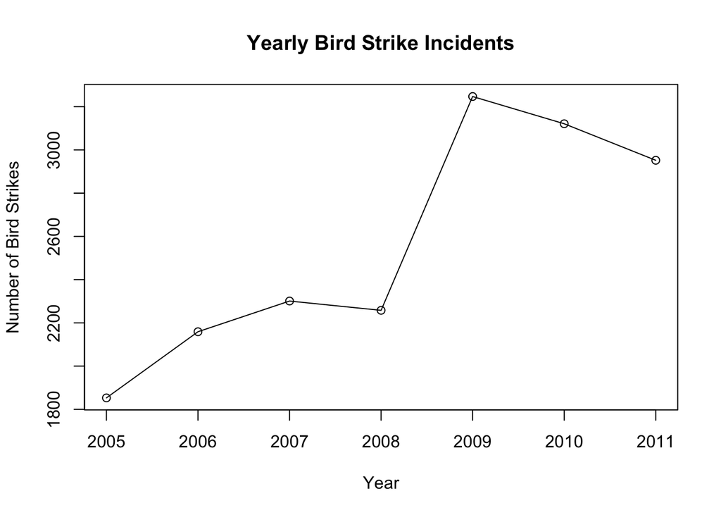

```r
yearly_strikes <-
  dbGetQuery(mydb, "SELECT YEAR(idate) AS year, COUNT(*) AS num_incidents
                      FROM incidents
                     GROUP BY year
                    HAVING year >= 2005 AND year <= 2011
                     ORDER BY year")

plot(x = yearly_strikes$year,
     y = yearly_strikes$num_incidents,
     type = "o",
     xlab = "Year",
     ylab = "Number of Bird Strikes",
     main = "Yearly Bird Strike Incidents")
```

## Question 8: Creating a procedure

### Procedure Creation

Create a stored procedure in MySQL (note that if you used SQLite, then you cannot complete this step) that adds a new incident to the database. You may decide what you need to pass to the stored procedure to add a bird strike incident and you must account for there being potentially a new airport. After insertion, show (in R) that your procedure worked. Note that if you used SQLite rather than the required MySQL for the practicum, then you cannot complete this question as SQLite does not support stored procedures.

```sql
DROP PROCEDURE IF EXISTS new_incident;
```

**Design decisions**

- `airportName` and `airline` will both be transformed to “UNKNOWN” if NULL.
- the `airportName` parameter is intended to uniquely identify an in the `airports` table. We chose to use `airportName` instead of an `aid` because `airportName` should still be unique and we wanted to create a user-friendly method.
- Note the creation and as necessary linking to the “UNKNOWN” airport.

```sql
CREATE PROCEDURE new_incident(
  new_rid INTEGER,
  new_idate DATE,
  new_airline TEXT,
  new_aircraft TEXT,
  new_flightPhase TEXT,
  new_altitude INTEGER,
  new_warning TINYINT(1),
  new_conditions INTEGER,
  new_airportName TEXT
)
BEGIN
  -- making airportname not null
  IF (new_airportName IS NULL) THEN
    SET new_airportName = "UNKNOWN";
  END IF;

  -- making airline name not null
  IF (new_airline IS NULL) THEN
    SET new_airline = "UNKNOWN";
  END IF;

  -- creating new airport entry, if necessary
  IF (SELECT aid
        FROM airports
       WHERE airportName LIKE new_airportName) IS NULL THEN
    INSERT INTO airports (airportName, airportCode, state) VALUES
      (new_airportName, NULL, NULL);
  END IF;

  -- finding appropriate aid
  SELECT aid
    FROM airports
   WHERE airportName LIKE new_airportName
    INTO @aid;

  -- inserting into incidents
  INSERT INTO incidents VALUES
    (new_rid, new_idate, @aid, new_airline, new_aircraft, new_flightPhase,
    new_altitude, new_conditions, new_warning);
END;
```

### Procedure Testing

Testing that insertion correctly renames NULL `airportName` and `airline` values and can insert a new airport (in this case, “UNKNOWN”) into the `airports` table.

```sql
CALL new_incident(
  1, "2022-10-22", NULL, NULL, NULL, NULL, NULL, NULL, NULL)
```

Testing that insertion correctly passes non-null values to insertion and can reference existing `airportName` values.

```sql
CALL new_incident(
  2,  "2022-10-23", "BUSINESS", "Airplane", "Landing", 589, FALSE, 2,
  "GREATER ROCKFORD")
```

Testing that insertion correctly creates new non-sentinel airport entry.

```sql
CALL new_incident(
  3,  "2029-10-31", "SPIRIT AIRLINES", "Giant Bat", NULL, -6, FALSE, 1,
  "SALEM INTL SCAREPORT")
```

Testing that procedure doesn’t bypass incidents table restrictions (eg. no duplicate values). Expect error.

```sql
CALL new_incident(
  2,  "2022-10-23", "BUSINESS", "Airplane", "Landing", 589, FALSE, 2,
  "GREATER ROCKFORD")
```

```
## Error in .local(conn, statement, ...): could not run statement: Duplicate entry '2' for key 'incidents.PRIMARY'
```

Showing new rows in incidents table. Note successful creation of 3 new rows.

```r
query <- "SELECT * FROM incidents WHERE rid IN (1, 2, 3)"

dbGetQuery(mydb, query)
```

```
##   rid      idate origin         airline  aircraft flightPhase altitude
## 1   1 2022-10-22   1108         UNKNOWN      <NA>        <NA>       NA
## 2   2 2022-10-23    378        BUSINESS  Airplane     Landing      589
## 3   3 2029-10-31   1109 SPIRIT AIRLINES Giant Bat        <NA>       -6
##   conditions warning
## 1         NA      NA
## 2          2       0
## 3          1       0
```

Showing new rows in airports table. Note 3 rows, two of which are new and one existing.

```r
query <- "SELECT * FROM airports
 WHERE aid IN (SELECT origin FROM incidents WHERE rid IN (1, 2, 3));"

dbGetQuery(mydb, query)
```

```
##    aid          airportName airportCode    state
## 1 1108              UNKNOWN        <NA>     <NA>
## 2  378     GREATER ROCKFORD        <NA> Illinois
## 3 1109 SALEM INTL SCAREPORT        <NA>     <NA>
```

## Disconnecting

```r
dbDisconnect(mydb)
```

```
## [1] TRUE
```